# Session 6: Sessions 2–5 in Review, and Three Advanced Techniques

Published course presentation · repository edition

Thierry Warin, PhD

HEC Montréal

## Outline · The hour ahead

1. Where we are — four sessions, one toolkit
2. Session 2 · describe one variable: goal, code, results, interpretation
3. Session 3 · fit a line, then check it
4. Session 4 · binary, ordinal and multinomial logistic regression
5. Session 5 · too many predictors: let the computer choose
6. Advanced · panel data, fixed or random effects
7. Advanced · interactions — a slope per group
8. Advanced · squared terms — effects that accelerate or level off
9. Key takeaways

## What session 6 is for

### The mathematics

- Summarise sessions 2 to 5 as goal, implementation, results and interpretation
- State what a **panel** is, and distinguish **fixed** from **random** effects
- Use the **Hausman test** to choose between fixed and random effects
- Read an **interaction** as a slope that differs between groups
- Read a **squared term** as an effect that accelerates or levels off

### The Python

- Fit fixed- and random-effects models with `PanelOLS` and `RandomEffects`
- Write an interaction (`a * b`) and a quadratic (`I(x**2)`) in a formula
- Interpret both in units, from the fitted coefficients

### The international business

- Separate within-country change from between-country difference
- Say which specification your identifying variation can actually support
- Report the estimate *and* the specification, because neither means much alone

## Your Python so far

Everything you need to type is on one sheet — how to start Python in VS Codium on your platform, how to make a file and run it, the DataFrame basics, and every name from sessions 1 to 6, each with a line showing it in use.

> **[Python Cheatsheet · Session 06](https://warint.github.io/quantitative-methods/python-cheatsheet-06.pdf)** (PDF) · in the repository at `06-…/PYTHON-CHEATSHEET.pdf`

**One sheet per package, functions explained with pictures:** [pandas](https://warint.github.io/quantitative-methods/python-cheatsheets/pandas.pdf) · [NumPy](https://warint.github.io/quantitative-methods/python-cheatsheets/numpy.pdf) · [matplotlib](https://warint.github.io/quantitative-methods/python-cheatsheets/matplotlib.pdf) · [statsmodels](https://warint.github.io/quantitative-methods/python-cheatsheets/statsmodels.pdf) · [linearmodels](https://warint.github.io/quantitative-methods/python-cheatsheets/linearmodels.pdf) · [scikit-learn](https://warint.github.io/quantitative-methods/python-cheatsheets/sklearn.pdf) · [SciPy](https://warint.github.io/quantitative-methods/python-cheatsheets/scipy.pdf)

Print it, or keep it open beside the editor. Nothing on it is examinable; all of it is assumed.

## Where we are

Four sessions, one toolkit. Each one answered a different kind of question:

| Session | The question | The method | The Python |
| --- | --- | --- | --- |
| **2** | What does one variable look like? | centre, spread, shape | `.mean()`, `.median()`, `.std()`, `stats.skew` |
| **3** | How does $y$ move with $x$ — and can we trust the line? | OLS, $R^2$, residuals, Cook’s distance | `smf.ols(...).fit()` |
| **4** | What if $y$ is a category? | logistic, ordinal, multinomial | `smf.logit`, `np.exp`, `.predict` |
| **5** | What if there are too many predictors? | stepwise, ridge, lasso, elastic net | `LassoCV`, `ElasticNetCV` |

The first part of today revisits the four, two slides each: **the goal and the code**, then **the results and their interpretation**, with the sentence you would write in a paper. The second part adds three techniques that make the regression of session 3 fit real data: **panels, interactions, squared terms**.

# Part 1 · Sessions 2–5 in review

## Session 2 · Describe one variable: the goal and the code

- Why describe first
- Centre, spread, shape
- The code

> **Before any model, know your variable.** How large is a typical value? How far apart are the values? Is the distribution symmetric, or does it have a long tail?

Example: **GDP per capita** across 30 European countries, 2009–2023 — one row per country-year.

- A regression in session 3 will use this variable. If it is strongly skewed, a few very rich countries can drive the result.
- The description decides later choices: report the mean or the median? Model GDP or its logarithm? Look for outliers?
- It also catches errors early: a negative GDP or a value ten times too large shows up here, not in a regression table.

|  | Measure | In plain words | Sensitive to extremes? |
| --- | --- | --- | --- |
| **Centre** | mean $\bar x = \frac{1}{n}\sum x_i$ | the balance point | yes |
|  | median | the middle value: half below, half above | no |
|  | trimmed mean | the mean after cutting 5% off each tail | little |
| **Spread** | standard deviation $s$ | typical distance from the mean | yes |
|  | IQR $= Q_3 - Q_1$ | width of the middle 50% | no |
| **Shape** | skewness $g_1$ | 0 = symmetric; $>0$ = long right tail | — |
|  | excess kurtosis $g_2$ | 0 = normal tails; $>0$ = more extreme values | — |

Rule of thumb: the distribution is **substantially skewed** if $|g_1| > 2\sqrt{6/n}$.

```python
from scipy import stats

core = qmib.load("core")                   # 30 countries x 15 years
gdp = core["gdp_pc_eur"].dropna()          # drop the missing years

summary = pd.Series({
    "mean": gdp.mean(),
    "median": gdp.median(),
    "5% trimmed mean": stats.trim_mean(gdp, 0.05),   # cut 5% from each tail
    "standard deviation": gdp.std(ddof=1),           # ddof=1: divide by n-1
    "IQR": gdp.quantile(0.75) - gdp.quantile(0.25),
    "skewness g1": stats.skew(gdp),
    "excess kurtosis g2": stats.kurtosis(gdp),
})
summary.round(2)
```

```
mean                  30372.66
median                25733.29
5% trimmed mean       29419.43
standard deviation    15419.54
IQR                   22215.47
skewness g1               0.88
excess kurtosis g2        0.00
dtype: float64
```

## Session 2 · Describe one variable: results and interpretation

- Results
- Interpretation
- What to write

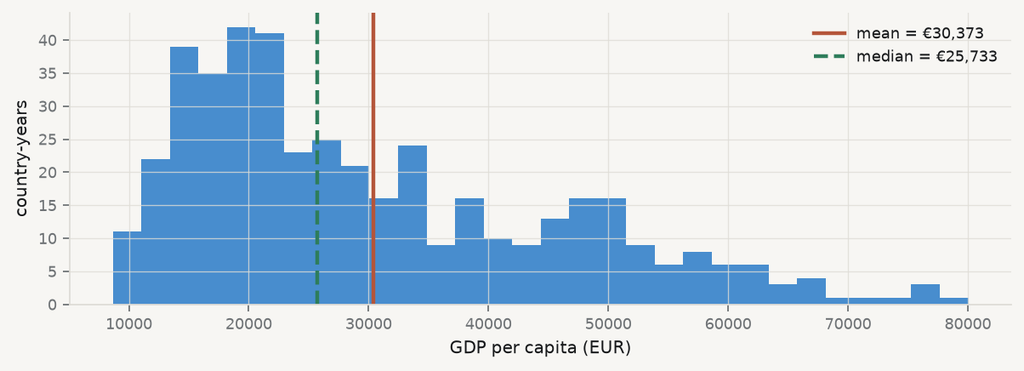

Most country-years sit between €10,000 and €45,000; a long tail runs to the right, out to €80,039.

- **Centre:** the mean (€30,373) is **above** the median (€25,733). A few very rich countries pull the mean up; the median does not move.
- **Shape:** skewness $g_1 =$ 0.88 is far above the threshold $2\sqrt{6/n} =$ 0.23: the distribution is **substantially right-skewed**.
- **Spread:** for a skewed variable, the IQR (€22,215) describes the typical range better than the standard deviation, which the tail inflates.
- **Consequence:** describe a “typical” country with the median and IQR, and consider modelling $\log(\text{GDP})$ later.

> “GDP per capita has a median of €25,733 (IQR €18,289–€40,505, n = 437 country-years). The distribution is right-skewed ($g_1 =$ 0.88), so we report medians.”

Every number in session 2 describes **one** variable at a time. Session 3 puts two in the same sentence.

## Session 3 · Fit a line, then check it: the goal and the code

- The question
- How OLS chooses the line
- The code

> **Do more productive European countries have higher income per head — and can we trust the answer?**

The model says GDP per capita ($y$) is a straight line in productivity ($x$), plus an error:

$$y_i = \beta_0 + \beta_1 x_i + \varepsilon_i$$

- $\beta_1$, the **slope**, is what we want: how much $y$ changes, on average, when $x$ is one unit higher.
- $\varepsilon_i$ is everything about country-year $i$ that productivity does not explain.

**Ordinary least squares** picks the line that makes the squared vertical distances as small as possible:

$$\min_{\beta_0,\,\beta_1} \sum_i \big(y_i - \beta_0 - \beta_1 x_i\big)^2$$

Squaring makes every miss count, above or below the line, and punishes big misses most. Then four checks, because fitting is the easy part:

| Question | Tool | A problem looks like |
| --- | --- | --- |
| **Adequacy** — how much does it explain? | $R^2$, adjusted $R^2$ | a small share explained |
| **Validity** — do the assumptions hold? | residual plot | a curve or a funnel |
| **Robustness** — does one row drive it? | Cook’s distance | one spike far above the rest |
| **Parsimony** — which model? | AIC, BIC | — lower is better |

```python
d = core.dropna(subset=["gdp_pc_eur", "productivity_idx"])   # rows with both values

# "gdp_pc_eur explained by productivity_idx"; the intercept is added for you
fit = smf.ols("gdp_pc_eur ~ productivity_idx", data=d).fit()

print(fit.params.round(1))                        # intercept and slope
print(f"R-squared = {fit.rsquared:.3f}   AIC = {fit.aic:,.0f}")
cooks_d = fit.get_influence().cooks_distance[0]   # one value per row
```

```
Intercept          -86118.1
productivity_idx     1111.3
dtype: float64
R-squared = 0.627   AIC = 9,046
```

## Session 3 · Fit a line, then check it: results and interpretation

- Results
- Interpretation
- What to write

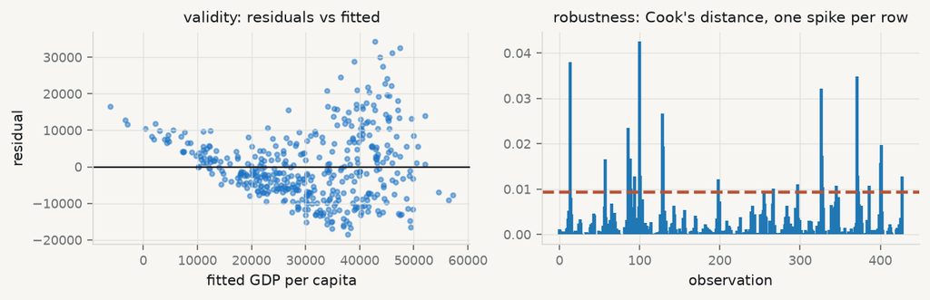

Left: residuals should scatter at random around zero. Right: the dashed line (4/n) is a prompt to look at a row, not a rule for dropping it.

- **The slope:** one more point of productivity goes with **€1,111 more** GDP per capita, on average. Say the units: euros per index point.
- **The intercept** (€-86,118) is the prediction at productivity 0, far outside the data (72 to 129). Do not interpret it.
- **Adequacy:** $R^2 =$ 0.63 — productivity accounts for 63% of the variation in GDP per capita. It says nothing about whether a straight line is the right shape.
- **Validity:** any curve or funnel in the residual plot is structure the line missed — a reason to try a squared term or a log (Part 2).
- **Robustness:** if one spike towers over the others, one country-year is carrying the result. Find out which, and report the fit with and without it.

> “Across 428 country-years, a one-point higher productivity index is associated with €1,111 higher GDP per capita (SE 42; $R^2 =$ 0.63).”

“Associated with”, not “causes”: the slope says the two move together. Higher income can also buy the capital that raises productivity.

## Session 4 · Two categories: binary logistic regression, the goal and the code

- The question
- Log-odds and maximum likelihood
- The code

> **Which loans default?** `default` is 1 if the borrower did not repay, 0 otherwise.
- A straight line through 0s and 1s (the *linear probability model*) can predict probabilities **below 0 or above 1**: for a very good credit score it predicts a negative chance of default.
- We need a model whose predictions always stay between 0 and 1. The **logistic** function does that: it bends the line into an S-shape.

| Outcome | Model | Python |
| --- | --- | --- |
| two categories (default or not) | logistic | `smf.logit` |
| ordered categories (unlikely < likely < very likely) | ordinal logit | `OrderedModel` |
| unordered categories (academic, general, vocational) | multinomial logit | `sm.MNLogit` |

The model is linear on the **log-odds** scale:

$$\ln\left(\frac{p}{1-p}\right) = \beta_0 + \beta_1\,\text{fico}, \qquad p = P(\text{default} = 1)$$

- $\frac{p}{1-p}$ is the **odds**: a probability of 0.2 is odds of 0.25, “one default for four repayments”.
- It is not fitted by least squares but by **maximum likelihood**: Python picks the $\beta$s that make the defaults and repayments we actually observed as probable as possible.
- The price: the coefficients come out as log-odds, which nobody reads directly. So we convert them, in two steps.

```python
loans = qmib.load("loans")
m = smf.logit("default ~ fico", data=loans).fit(disp=0)   # maximum likelihood

print(m.params.round(4))                         # step 0: log-odds
print(np.exp(m.params["fico"]).round(4))         # step 1: odds ratio
# step 2: probabilities, inside the range of the data (FICO 612 to 827)
m.predict(pd.DataFrame({"fico": [650, 700, 800]})).round(3)
```

```
Intercept    6.7189
fico        -0.0119
dtype: float64
0.9882
```

```
0    0.269
1    0.169
2    0.058
dtype: float64
```

## Session 4 · Two categories: binary logistic regression, results and interpretation

- Results
- Step 1 · Log-odds
- Step 2 · Odds
- Step 3 · Probabilities
- What to write

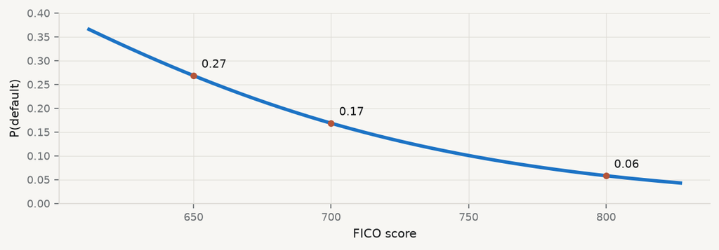

The predicted probability of default falls as the credit score rises — and never leaves the 0–1 range.

Python prints $b_1 =$ -0.0119. Read it in two passes.

**First the sign.** It is negative: a higher FICO score goes with a **lower** chance of default. The sign is the one thing you can read straight from a log-odds coefficient — positive raises the chance, negative lowers it.

**Then the size.** “One more FICO point lowers the log-odds of default by 0.0119.” That sentence is correct, but nobody thinks in log-odds: a reader cannot tell whether 0.0119 is a lot or a little.

- Why does the model use log-odds at all? Because on that scale the relationship is a **straight line**: every extra point changes the log-odds by the same amount, wherever you start.
- So the log-odds are the model’s working scale. To talk to a reader, we convert them — first to **odds**, then to **probabilities**.

**What are odds?** The chance that something happens divided by the chance that it does not: $\text{odds} = p / (1 - p)$.

| probability of default $p$ | odds $p/(1-p)$ | in words |
| --- | --- | --- |
| 0.50 | 1.00 | one default for every one repayment |
| 0.20 | 0.25 | one default for every four repayments |
| 0.169 (FICO 700) | 0.203 | about one default for every 5 repayments |

**The odds ratio** $e^{b_1} =$ 0.988 is a **multiplier**: each extra FICO point multiplies the odds by 0.988, i.e. lowers them by 1.2%, holding everything else constant (*ceteris paribus*).

- Check it: odds at 700 = 0.2028; at 701 = 0.2028 × 0.988 = 0.2004.
- For a bigger step, multiply the coefficient first: 100 points → $e^{100 \times b_1} =$ 0.305, odds about 70% lower. From 700 to 800 the odds fall from 0.203 to 0.062.
- The rule: if $e^b > 1$ the odds rise by $(e^b - 1) \times 100\%$; if $e^b < 1$ they fall by $(1 - e^b) \times 100\%$.

Odds are still not what most readers want. For a **probability**, put the whole linear predictor through the logistic function: $p = e^{b_0 + b_1 x} / (1 + e^{b_0 + b_1 x})$. That is what `predict()` does.

| FICO score | 650 | 700 | 750 | 800 |
| --- | --- | --- | --- | --- |
| probability of default | 0.269 | 0.169 | 0.101 | 0.058 |
| change over the previous 50 points | — | -0.100 | -0.068 | -0.042 |

- Every 50-point step multiplies the odds by the **same** factor, yet the probability falls by less and less. The S-curve is steepest where defaults are common and flattens where they are already rare.
- So a logistic model has **no single “effect on the probability”**: it depends on where the borrower starts. Report probabilities at a few meaningful values — and only inside the scores you observed (612 to 827).

> “Each additional FICO point is associated with 1.2% lower odds of default (odds ratio 0.988). The predicted probability of default falls from 0.27 at a score of 650 to 0.06 at 800.”

Never report a log-odds as if it were a probability, and never predict outside the scores you observed.

## Session 4 · Ordered categories: ordinal logistic regression

- Goal
- Code
- Results
- Reading the odds ratios
- Reading the probabilities
- Common mistakes

> **How likely is a student to apply to graduate school?** The answer is *unlikely* < *somewhat likely* < *very likely*: three categories with a natural **order**.
- A binary logit would throw information away (collapse to two categories); a multinomial logit would ignore the order.
- The **ordinal logit** models the **cumulative** log-odds — the chance of being *at or below* each cut:

$$\ln\left(\frac{P(Y \le j)}{P(Y > j)}\right) = c_j - (\beta_1\,\text{pared} + \beta_2\,\text{public} + \beta_3\,\text{gpa}), \qquad j = 1, 2$$

- Two **cutpoints** $c_1 < c_2$ act as intercepts, one per cut. There is **one** $\beta$ per predictor, the same at both cuts: the **proportional-odds** assumption.
- Because of the minus sign, a **positive** $\beta$ pushes students **up** the scale.

```python
from statsmodels.miscmodels.ordinal_model import OrderedModel

dat = qmib.load("ologit")
order = ["unlikely", "somewhat likely", "very likely"]
dat["apply_c"] = pd.Categorical(dat["apply"], categories=order, ordered=True)  # keep the order

om = OrderedModel(dat["apply_c"], dat[["pared", "public", "gpa"]], distr="logit").fit(method="bfgs", disp=0)
b_o = om.params[["pared", "public", "gpa"]]
pd.DataFrame({"log-odds": b_o, "odds ratio": np.exp(b_o), "p-value": om.pvalues[b_o.index]}).round(3)
```

|  | log-odds | odds ratio | p-value |
| --- | --- | --- | --- |
| pared | 1.048 | 2.851 | 0.000 |
| public | -0.059 | 0.943 | 0.844 |
| gpa | 0.616 | 1.851 | 0.018 |

```python
# Two otherwise identical students (private school, GPA 3.0): parents with or without graduate school
new = pd.DataFrame({"pared": [1, 0], "public": [0, 0], "gpa": [3.0, 3.0]})
probs_o = pd.DataFrame(np.asarray(om.predict(new)), columns=order, index=["pared = 1", "pared = 0"])
probs_o.round(3)
```

|  | unlikely | somewhat likely | very likely |
| --- | --- | --- | --- |
| pared = 1 | 0.334 | 0.469 | 0.197 |
| pared = 0 | 0.588 | 0.333 | 0.079 |

Each row sums to 1. The model computes $P(Y \le j) = F(c_j - x\beta)$ and takes differences to get each category.

**What does “a higher category” mean?** There are two cuts: *somewhat or very likely* versus *unlikely*, and *very likely* versus the rest. An odds ratio says how the odds of being **above a cut** change — and, by proportional odds, it is the **same at both cuts**.

**`pared`** (a parent went to graduate school): $b =$ 1.048, positive, so it pushes students **up** the scale. $e^{b} =$ 2.85: their odds of being above any cut are 2.85 times those of other students — 185% higher.

Check it with the predicted probabilities from the Results tab, at the first cut:

|  | $P(\text{somewhat or very likely})$ | odds |
| --- | --- | --- |
| `pared = 0` | 0.412 | 0.700 |
| `pared = 1` | 0.666 | 1.997 |

and 1.997 / 0.700 = 2.85 — the odds ratio.

**`gpa`:** $e^{b} =$ 1.85 per full GPA point. A full point is a big move (GPA’s standard deviation is about 0.4); for a 0.4-point rise the odds ratio is $e^{0.4\,b} =$ 1.28.

**`public`:** $p =$ 0.84. The data cannot tell its effect from zero: report “no detectable effect”, not “6% lower odds”.

The Results table, row by row:

- Each row is a full distribution over the three answers, so it **sums to one**. Raising one category means lowering another.
- Moving `pared` from 0 to 1 takes $P(\text{unlikely})$ from 0.59 down to 0.33, and $P(\text{very likely})$ from 0.08 up to 0.20. One coefficient shifts the **whole distribution** up the scale.
- The **middle** category can go either way: it gains students from below and loses some to above. Here it moves from 0.33 to 0.47.
- This is why you show probabilities: an odds ratio of 2.85 does not tell a reader that the share of “very likely” students more than doubles.
- **The sign convention.** statsmodels writes $c_j - x\beta$, so a positive $\beta$ means *higher* categories. Some software writes $c_j + x\beta$; check before you read a sign.
- **Proportional odds is an assumption**, not a result. Fit a separate binary logit at each cut: if the slopes differ a lot, one number is the wrong summary (session 4, Appendix C).
- **The cutpoints** are not effects: they only place the thresholds between categories. Do not interpret them as you would a coefficient.

## Session 4 · Unordered categories: multinomial logistic regression

- Goal
- Code
- Results
- Reading the ratios
- Reading the probabilities
- Common mistakes

> **Which high-school programme does a student follow — academic, general or vocational?** Three categories with **no order**: vocational is not “more” than general.
- Pick a **baseline** category (academic, the most common). The model writes one log-odds equation **per other category**, each against the baseline:

$$\ln\frac{P(\text{general})}{P(\text{academic})} = b_{10} + b_{11}\,\text{middle} + b_{12}\,\text{high} + b_{13}\,\text{write}$$

$$\ln\frac{P(\text{vocation})}{P(\text{academic})} = b_{20} + b_{21}\,\text{middle} + b_{22}\,\text{high} + b_{23}\,\text{write}$$

- Unlike the ordinal model, every predictor gets **its own coefficient in each equation**. The equations are estimated together by maximum likelihood, so the three probabilities sum to one.

```python
import statsmodels.api as sm

ml = qmib.load("hsbdemo")
levels = ["academic", "general", "vocation"]            # code 0 = academic = the baseline
y_m = pd.Categorical(ml["prog"], categories=levels).codes
X_m = pd.get_dummies(ml["ses"])[["middle", "high"]].astype(float)   # low SES is the reference
X_m["write"] = ml["write"].astype(float)
mn = sm.MNLogit(y_m, sm.add_constant(X_m)).fit(disp=0)

b_m = mn.params.set_axis(["general vs academic", "vocation vs academic"], axis=1)
pd.concat({"log-odds": b_m, "RRR": np.exp(b_m)}, axis=1).round(3)
```

|  | log-odds general vs academic | log-odds vocation vs academic | RRR general vs academic | RRR vocation vs academic |
| --- | --- | --- | --- | --- |
| const | 2.852 | 5.218 | 17.326 | 184.602 |
| middle | -0.533 | 0.291 | 0.587 | 1.338 |
| high | -1.163 | -0.983 | 0.313 | 0.374 |
| write | -0.058 | -0.114 | 0.944 | 0.893 |

```python
# Middle-SES students across the range of writing scores
grid_m = pd.DataFrame({"const": 1.0, "middle": 1.0, "high": 0.0, "write": [35, 45, 55, 65]})
probs_m = pd.DataFrame(mn.predict(grid_m).values, columns=levels, index=grid_m["write"])
probs_m.round(3)
```

| write | academic | general | vocation |
| --- | --- | --- | --- |
| 35 | 0.143 | 0.192 | 0.665 |
| 45 | 0.309 | 0.232 | 0.460 |
| 55 | 0.527 | 0.221 | 0.252 |
| 65 | 0.720 | 0.169 | 0.110 |

The model computes $P(Y = j) = e^{\eta_j} / \sum_k e^{\eta_k}$ (the **softmax**), with $\eta = 0$ for the baseline.

**Everything is relative to the baseline** (academic). A relative risk ratio (RRR) multiplies the ratio $P(\text{category}) / P(\text{academic})$ — how many students are in that programme for every academic one.

**`write`, general vs academic:** RRR = 0.944. Each extra writing point multiplies the general-to-academic ratio by 0.944: 5.6% lower. Over 10 points, multiply the coefficient by 10: $e^{10b} =$ 0.56 — the ratio is almost halved.

**`write`, vocation vs academic:** RRR = 0.893 per point, $e^{10b} =$ 0.32 over 10 points. Writing pulls students away from vocation **faster** than away from general.

**`high` SES, general vs academic:** RRR = 0.313 ($p =$ 0.024). Compared with a low-SES student, a high-SES student’s general-to-academic ratio is about a third.

**`middle` SES:** $p =$ 0.23 and 0.54 — no detectable difference from low SES in either equation.

From the Results table, middle-SES students:

| writing score | 35 | 45 | 55 | 65 |
| --- | --- | --- | --- | --- |
| academic | 0.14 | 0.31 | 0.53 | 0.72 |
| general | 0.19 | 0.23 | 0.22 | 0.17 |
| vocation | 0.66 | 0.46 | 0.25 | 0.11 |

- Academic rises steadily and vocation falls steadily: easy to read.
- **General first rises, then falls** — even though its coefficient on `write` is negative. Why? Vocation loses students faster than general does, and some of the weakest writers who leave vocation land in general.
- The lesson: a coefficient tells you how a category moves **against the baseline**, not how its own probability moves. Only the probabilities show that.
- **Forgetting the baseline.** Every coefficient is “relative to academic”. Choose another baseline and every number changes — so always name it.
- **Reading a negative coefficient as “less likely”.** As the General row shows, a category’s probability can rise while its coefficient is negative.
- **Comparing two non-baseline categories directly.** General vs vocation is not in the output; it is the difference of their coefficients, $b_{1k} - b_{2k}$.
- **Small categories** give unstable estimates: check how many students each programme has before trusting a coefficient.

## Session 5 · Too many predictors: the goal and the code

- The question
- Four ways to choose
- The code

> **Which of 29 candidate predictors explain R&D intensity, with only 37 countries?**
- With almost as many predictors as rows, OLS **fits the noise**: large coefficients, wrong signs, useless variables kept. It looks perfect on the data it was fitted to and fails on new data.
- Choosing the predictors by hand is slow and subjective. So we **automate model selection**.

| Method | What it does | In one phrase |
| --- | --- | --- |
| **Stepwise** (old style) | adds one predictor at a time while **AIC** improves | a greedy loop |
| **Ridge** | keeps all predictors, **shrinks** every coefficient | a tax on big coefficients |
| **Lasso** | shrinks, and sets the weak ones to **exactly zero** | an entry fee: the weak leave |
| **Elastic net** | a mix: zeros like the lasso, keeps correlated predictors **together** | our default |

The three penalised methods all minimise

$$\sum_i (y_i - \hat y_i)^2 + \lambda \times \text{size of the coefficients}$$

$\lambda$ (`alpha` in Python) sets the price: 0 gives OLS, a huge value pushes everything to 0. **Cross-validation** chooses it, and the predictors must be **standardised** first.

```python
def test_rmse(model):                  # fit on 70% of rows, score on the other 30%
    pipe = make_pipeline(StandardScaler(), model).fit(Xtr, ytr)   # standardise first
    kept = int(np.sum(np.abs(pipe[-1].coef_) > 1e-8))             # non-zero coefficients
    return kept, mean_squared_error(yte, pipe.predict(Xte)) ** 0.5

results = {
    "OLS, all predictors": test_rmse(LinearRegression()),
    "ridge":       test_rmse(RidgeCV(alphas=np.logspace(-3, 3, 60))),   # λ by CV
    "lasso":       test_rmse(LassoCV(cv=5, random_state=0, max_iter=50_000)),
    "elastic net": test_rmse(ElasticNetCV(l1_ratio=0.5, cv=5, random_state=0, max_iter=50_000)),
}
```

## Session 5 · Too many predictors: results and interpretation

- Results
- Interpretation
- What to write

```python
res.round(3)
```

|  | predictors kept | test RMSE |
| --- | --- | --- |
| OLS, all predictors | 29 | 0.483 |
| ridge | 29 | 0.227 |
| lasso | 6 | 0.195 |
| elastic net | 8 | 0.198 |

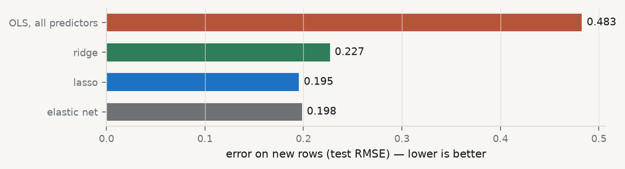

- **OLS with every predictor** has the largest error on rows it never saw (0.483): it learned the noise of the training rows.
- The **penalised models** cut that error by more than half. Nothing was added — the coefficients were only restrained.
- **Ridge** keeps all 29 predictors; the **lasso** keeps 6 and the **elastic net** 8. When predictors come in correlated groups, the elastic net keeps the group, which is why it is our default.

> “We selected predictors with an elastic net (mix 0.5, λ chosen by 5-fold cross-validation on standardised predictors). It keeps 8 of 29 candidates and reduces the test error from 0.483 (OLS) to 0.198.”

Do not write “these are the variables that matter”: the selection is *a* set that predicts well on this sample. And no $p$-values after selection.

# Part 2 · Three advanced techniques

## Panel data: the same countries, year after year

- The idea
- The code

A **panel** follows the same entities (countries, firms) over several periods. Here: government debt and economic-freedom indices for countries over the years.

- Countries differ in many ways we do not measure — institutions, history, culture. If those also affect debt, a plain regression mixes them into the slopes.
- **Fixed effects (FE):** give each country its own intercept. Only changes **within** a country over time identify the slopes, so anything constant about a country is controlled for.
- **Random effects (RE):** treat the country differences as random noise. More efficient, but only valid if those differences are unrelated to the predictors.

$$\text{debt}_{it} = \alpha_i + \beta_1\,\text{busfreedom}_{it} + \beta_2\,\text{finfreedom}_{it} + \beta_3\,\text{invfreedom}_{it} + \varepsilon_{it}$$

$\alpha_i$ is the country’s own intercept; $i$ is the country, $t$ the year.

```python
from linearmodels.panel import PanelOLS, RandomEffects

mydata1 = qmib.load("panel")
cols = ["grossdebt", "busfreedom", "finfreedom", "invfreedom"]
panel = mydata1.dropna(subset=cols).set_index(["country", "year"])   # entity, then time
y, X = panel["grossdebt"], panel[["busfreedom", "finfreedom", "invfreedom"]]

fixed = PanelOLS(y, X, entity_effects=True).fit()     # one intercept per country
random_ = RandomEffects(y, X).fit()
pd.DataFrame({"fixed effects": fixed.params, "random effects": random_.params}).round(3)
```

|  | fixed effects | random effects |
| --- | --- | --- |
| busfreedom | -0.372 | -0.118 |
| finfreedom | -0.334 | -0.233 |
| invfreedom | 0.652 | 0.695 |

## Panel data: fixed or random effects?

- The Hausman test
- Interpretation

If FE and RE give **similar** coefficients, RE is fine (and more precise). If they **differ** by more than sampling noise, RE is inconsistent: use FE.

```python
from scipy import stats

diff = fixed.params - random_.params
vdiff = fixed.cov - random_.cov
H = float(diff.values @ np.linalg.pinv(vdiff.values) @ diff.values)
p_value = stats.chi2.sf(H, len(diff))
print(f"Hausman H = {H:.2f} on {len(diff)} df,  p = {p_value:.4f}")
```

```
Hausman H = 27.59 on 3 df,  p = 0.0000
```

- **Small $p$ (below 0.05):** the two disagree → use **fixed effects**.
- **Large $p$:** no evidence they disagree → **random effects** is acceptable, and more precise.
- A fixed-effects slope answers a **within** question: when a country’s business freedom rises, what happens to *its* debt? It cannot say why some countries have more debt than others.

Rejecting says random effects is wrong here — not that fixed effects is right. And report which one you used: the same data can give different answers under each.

## Interactions: a slope that differs between groups

- The idea
- The code

Does bonus pay fall with age **at the same rate** for men and women? A plain regression `bonus ~ age + female` assumes yes. An **interaction** lets the slope differ:

$$\text{bonus} = \beta_0 + \beta_1\,\text{age} + \beta_2\,\text{female} + \beta_3\,(\text{age} \times \text{female})$$

- For men (female = 0): slope in age $= \beta_1$
- For women (female = 1): slope in age $= \beta_1 + \beta_3$
- $\beta_3$ is the **difference** between the two slopes. If $\beta_3 = 0$, the effect of age is the same for both.

```python
glassdoor = qmib.load("glassdoor")
glassdoor["female"] = (glassdoor["gender"].str.lower() == "female").astype(int)

# age * female expands to age + female + age:female
fit6 = smf.ols("bonus ~ age * female", data=glassdoor).fit()
b = fit6.params
print(f"slope in age, men   : {b['age']:8.2f} per year")
print(f"slope in age, women : {b['age'] + b['age:female']:8.2f} per year")
print(f"difference          : {b['age:female']:8.2f}   p = {fit6.pvalues['age:female']:.4f}")
```

```
slope in age, men   :   -51.45 per year
slope in age, women :   -66.83 per year
difference          :   -15.38   p = 0.0592
```

## Interactions: reading the result

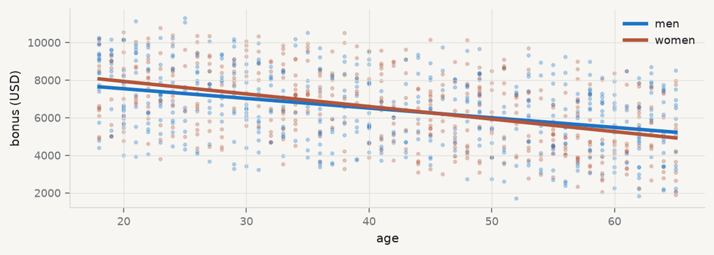

- Bonus falls with age for both groups: by 51.4 dollars a year for men, 66.8 for women.
- The difference between the slopes (-15.4) has $p =$ 0.059: **not significant at 5%**, so we cannot say the age effect differs by gender.
- The `female` coefficient alone is the gap **at age 0** — a value no employee has. With an interaction, read the two slopes, not each coefficient separately.

## Squared terms: when the effect is not a straight line

- The idea
- The code

Does each extra square foot add the same amount to a house’s price, or does the effect **accelerate**? Add the predictor **squared**:

$$\text{price} = \beta_0 + \beta_1\,\text{area} + \beta_2\,\text{area}^2$$

- $\beta_2 > 0$: the effect **accelerates** (a U-shape, upward curve). $\beta_2 < 0$: it **levels off** (an inverted U).
- The effect of one more square foot is no longer one number: it is $\beta_1 + 2\beta_2 \times \text{area}$, so it depends on the size of the house.
- It is still a **linear** regression: linear in the coefficients. Squares, logs, interactions are all allowed.

```python
re_data = qmib.load("realestate")

re1 = smf.ols("price ~ living_area", data=re_data).fit()
re2 = smf.ols("price ~ living_area + I(living_area**2)", data=re_data).fit()   # I() = "compute this"

print(re2.params.round(4))
print(f"p-value on the squared term = {re2.pvalues['I(living_area ** 2)']:.5f}")
print(f"adjusted R2: straight line {re1.rsquared_adj:.3f}  ->  with square {re2.rsquared_adj:.3f}")
```

```
Intercept              471374.9775
living_area              -110.7200
I(living_area ** 2)         0.0408
dtype: float64
p-value on the squared term = 0.00001
adjusted R2: straight line 0.134  ->  with square 0.152
```

## Squared terms: reading the result

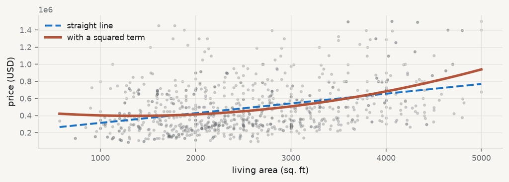

- $\beta_2 =$ 0.0408 is positive and significant: the price **accelerates** with size.
- One more square foot adds about **$12** to a 1,500 sq. ft house, but **$134** to a 3,000 sq. ft one.
- Check the curve stays sensible over the range of your data — never extrapolate a quadratic beyond it.

## Key takeaways

1. **Session 2** — describe before you model: centre, spread, shape; median and IQR when the data are skewed
2. **Session 3** — a slope is a sentence with units; then check adequacy, validity and robustness
3. **Session 4** — for a category: log-odds → $e^{b}$ for odds → $e^{xb}/(1+e^{xb})$ for probabilities
4. **Session 5** — with many predictors, let a penalty choose; the elastic net is the default
5. **Panels** — fixed effects use only within-entity change; the Hausman test chooses FE or RE
6. **Interactions** — `a * b` gives a slope per group; read the slopes, not the coefficients alone
7. **Squared terms** — `I(x**2)` lets an effect accelerate or level off

## Before the next session

**Required:** the next session’s article, its Dataverse package, and the self-check. That is the pre-session deck.

**Optional:** the **QMIB Lab** for this session — a knowledge check on the hour you have just sat through: **[warin.ca/qmib-labs](https://warin.ca/qmib-labs/qmib-lab-06.html)**

Never a prerequisite, never marked for correctness. A completed report counts toward participation because attempting it is the engagement being measured.